# Olasılık

Ali Valiyev

2024-03-26

Olasılık dağılımları 2 türdür. Kesikli dağılımlar ve Sürekli dağılımlar. Kesikli dağılımlar: Bernouilli Dağılımı Binom Dağılımı Poısson Dağılımı Hipergeometrik Dağılım

Sürekli Dağılımlar: Üstel Dağılım Uniform Dağılım Normal Dağılım

```r
#install.packages("Rlab")
library(Rlab)
```

Bernouilli Dağılımını denemek için ilk önce “Rlap” Paketini indirmemiz ve çalıştırmamız gerekiyor.

```r
?dbern
```

```
## starting httpd help server ... done
```

Bernouilli dağılımıyla kullanabileceğimiz fonksiyonlara bakalım. dbern - qbern - pbern - rbern -

```r
dbern(x = 0, prob = 0.6)
```

```
## [1] 0.4
```

x - hangi durumun kazanma olasılığını hesaplayacagız prob - olasilik degeri Buradaki 0.4 anlamı x-ın Kazanma olasığını gösteriyor. Yani prob = 0.6 olma durumunda x-ın 0.4 ihtimalle kazanma şansı vardır.

```r
dbern(x = 1, prob = 0.6)
```

```
## [1] 0.6
```

prob default olarak x-ın 1 olma durumu için hesapedilmiştir. Yani prob = 0.6 olma durumunda x-ın 0.6 ihtimalle kazanma şansı vardır.

```r
dbern(x = 2, prob = 0.6)
```

```
## [1] 0
```

Yani x-ın 2 olma durumu mümkün değildir.

```r
pbern(q = 1 , prob = 0.8)
```

```
## [1] 1
```

Neden 1 oldu?

```r
?norm
```

Normal Dağılım: Normal dağılım sürekli bir dağılımdır. Normal dağılımda ilgi alanımız ortalama ve standart sapma değerlerdir. Normal dağılımla kullanabileceğimiz fonksiyonlara bakalım.

```r
?norm
```

dnorm - sadece bir tane sayıyı bulma olasılığını hesaplar. pnorm - herhangı bır değere göre kumilatif olasılığı hesaplıyoruz qnorm - olasılık değerine istinaden hangi değeri en az ve ya en fazla elde edebilmemizin sonucunu buluyor rnorm - random dagilan veri oluşturmak için kullanılır **************************************************************** mean - ortalama sd - standart sapma lower.tail - —————————————————————-

dnorm kullanımı: x - elde etmek istediğimiz olasılık değerini giriyoruz hangi popilasyondan elde edeceğimizi ortalama ve standart sapma yardımı ile belirteceğiz.

```r
dnorm( x = 20, mean = 30, sd = 5 )
```

```
## [1] 0.01079819
```

Daha detaylı bir inceleme için Plot çizelim.

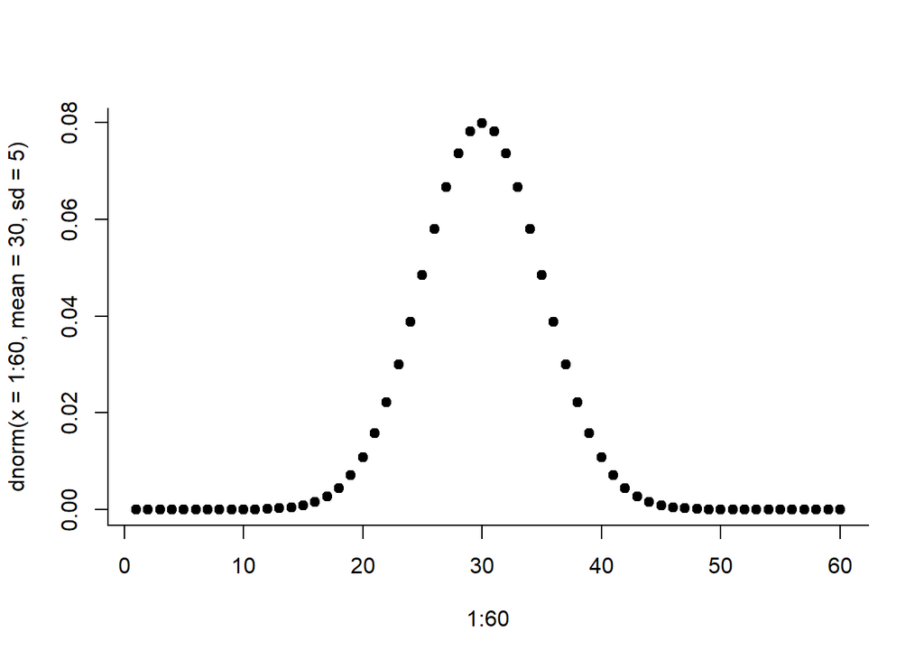

```r
plot( 1:60 , dnorm( x = 1:60, mean = 30 , sd = 5) ,
      bty = "L",
      pch = 19
      )
```

Sonuç olarak bir çan eğrisi oluştu. Dağılıma baktığımızda bu dağılımın Normal bir dağılım olduğunu söyleyebiliriz. Olasılık 20-de artmaya başlamış 30 noktasında max seviyeye ulaşmış durumdadır. Daha sonra 0-a doğru azalmaya başlıyor. mean 30-a eşit olduğu için 30-u elde etme olasılığımız en yüksek olasılıktır. Ortalamadan uzaklaştıkdaysa Olasılığımız düşerek azalıyor. ********************************************************************************************************************************

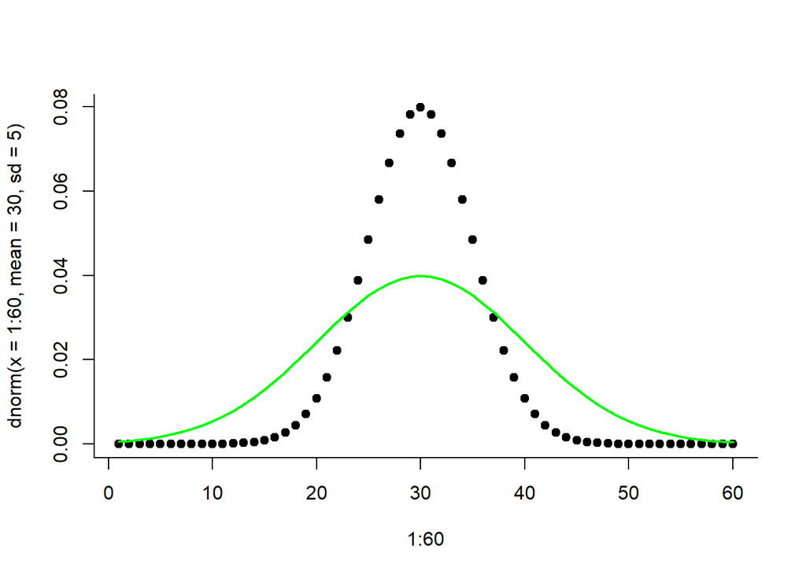

```r
plot( 1:60 , dnorm( x = 1:60, mean = 30 , sd = 5) ,
      bty = "L",
      pch = 19
      )
lines(dnorm( x = 1:60, mean = 30 , sd = 10) , lwd = 2, col = "green")
```

standart sapma değeri artdığında Dağılımın eğriliği azaldı. Çünkü Standart sapma artdıkca ortalamadan uzaklaşıyoruz. Bu Dağılıma bakarak Standart Sapmanın Dağılımsa nasıl bir etki etdiğini görebiliyoruz. Olasılık değerindeki düşüşün sebebi her standart sapmada aldığımız olasılık değerlerinin 1-e eşit olmasından kaynaklanıyor. ********************************************************************************************************************************

pnorm - Hava sıcaklığının ortalaması 40 derecedir. Standart sapma 5 derece Hava sıcaklığının 30 dereceden yüksek olma olasılığı

```r
pnorm( q = 30 , mean = 40 , sd = 5, lower.tail = FALSE)
```

```
## [1] 0.9772499
```

Bu kadar yüksek olmasının sebebi standart sapmayı çıkardıkda bile 35 kalıyor.

```r
#30-dan az olması:
pnorm( q = 30 , mean = 40 , sd = 5, lower.tail = TRUE)
```

```
## [1] 0.02275013
```

```r
#35-den az olması:
pnorm( q = 35 , mean = 40 , sd = 5, lower.tail = TRUE)
```

```
## [1] 0.1586553
```

değeri artırdığımız için olasılık değeri de artmaya başladı.

```r
#40-dan az olması:
pnorm( q = 40 , mean = 40 , sd = 5, lower.tail = TRUE)
```

```
## [1] 0.5
```

40 Dağılımın tam ortası olduğu için simetrik bir şekilde olasılığımız 0.5 - e eşit oldu. Yani Dağılımımız simetrik bir dağılımdır. 40-dan fazla olma olasılığı da 0.5 - e eşit olucaktır. ********************************************************************************************************************************

qnrom fonksiyonu - belirtiğimiz olasılığa uygun değer elde etmek için kullanılır.

```r
qnorm( p = 0.4 , mean = 40 , sd = 5, lower.tail = FALSE)
```

```
## [1] 41.26674
```

Yüzde 40 olasılıkla 41-den fazla bir değer elde edeceğimizi söylüyor

```r
qnorm( p = 0.4 , mean = 40 , sd = 5, lower.tail = TRUE)
```

```
## [1] 38.73326
```

Yüzde 40 olasılıkla 38-den az bir değer elde edeceğimizi söylüyor ********************************************************************************************************************************

rnorm - random Normal dağılan veri üretme n - Ne kadar sayıda Normal Dağılan veri oluşturacağımızı belirtmek için kullanıyoruz.

```r
rnorm ( n = 30 , mean = 40 , sd = 5)
```

```
##  [1] 36.03600 44.26946 41.18980 41.58345 39.70907 41.29583 35.70955 39.41892
##  [9] 36.94921 34.35166 43.58236 45.91096 43.07872 39.36236 35.10352 44.52386
## [17] 34.44015 42.45413 40.89579 39.48407 37.57639 35.92337 49.17361 44.15820
## [25] 33.77896 35.90067 36.70204 38.66872 47.08955 38.44421
```

```r
RData = rnorm ( n = 30 , mean = 40 , sd = 5)
mean(RData)
```

```
## [1] 39.49488
```

```r
sd(RData)
```

```
## [1] 6.650655
```

Ortalama ve Standart sapmasının tam bi şekilde olmamasının sebebi rastgele oluşturduğumuzdan dolayıdır.

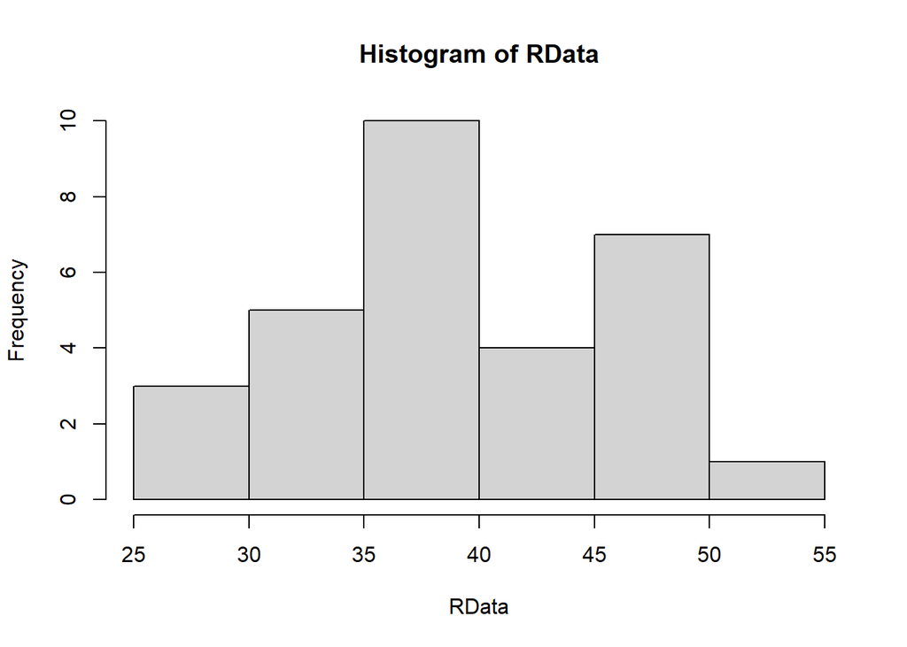

```r
hist(RData)
```

```r
pnorm( q = 15, mean = 10, sd = 2 , lower.tail = TRUE  )
```

```
## [1] 0.9937903
```

P(x <= 10 ) ?

```r
pnorm( q = 10, mean = 10, sd = 2 , lower.tail = TRUE  )
```

```
## [1] 0.5
```

P(8<x<11)?

```r
P = 1 - pnorm( q = 11, mean = 10, sd = 2 , lower.tail = FALSE  ) - pnorm( q = 8, mean = 10, sd = 2 , lower.tail = TRUE  )
P
```

```
## [1] 0.5328072
```

P(x<20)?

```r
pnorm( q = 20, mean = 10, sd = 2 , lower.tail = TRUE  )
```

```
## [1] 0.9999997
```